# Let's build an AFL sports betting model

# Contents

#### 0. Introduction

- 0.1 Data
- 0.2 Model inputs
- 0.3 Model outputs

#### 1. Setup

#### 2. Feature engineering

- 2.1 Further features
- 2.2 Aggregate team stats from player stats
- 2.3 Create features
- 2.4 Choose the lags and stats

#### 3. Train the model

- 3.1 Setup the training and test data
- 3.2 Feature selection
- 3.3 Model selection

#### 4. Model evaluation

- 4.1 Evaluate odds' predictions
- 4.2 Evaluate model's predictions
- 4.3 Evaluate model by simulating betting

#### 5. Next steps

# 0. Introduction

We are asked to build a classification model that predicts the winner of an AFL match

### 0.1 Data

We have 2012-2016 data to train the model, which we will evaluate on 2017 data. The data includes player stats for every match.

### 0.2 Model inputs

Our model will be indifferent to which teams are playing, and only consider the home and away teams' recent stats

### 0.3 Model outputs

Our model output will be the predicted probability the home team winning

- We chose this because we have been given odds for match win/loss. Hence we can compare the model output to the given odds to see if we can do better than the odds.
- We chose this output over classification (win/lose) because this output would not be informative for betting. If the model predicts a home win, but so do the odds, should the user bet or not?
- A model that predicts home win margin would also by definition predict home win/loss. If we were interested in betting in margin betting markets and had the odds data, that would have been a useful output.

# 1. Setup

```python
import numpy as np
import pandas as pd
```

```python
# Import the results table
results = pd.read_csv("source_data/afl_match_results.csv")

# Add some basic columns
results["Year"] = results["Date"].map(lambda x: int(x[:4]))
results["home_win"] = np.nan
results.loc[results.Margin > 0, "home_win"] = 1
results.loc[results.Margin == 0, "home_win"] = 0.5
results.loc[results.Margin < 0, "home_win"] = 0

results.head()
```

|  | Date | Round | Home.Team | Home.Goals | Home.Behinds | Home.Points | Away.Team | Away.Goals | Away.Behinds | Away.Points | Venue | Margin | Season | Round.Type | home_win | Year |
| --- | --- | --- | --- | --- | --- | --- | --- | --- | --- | --- | --- | --- | --- | --- | --- | --- |
| 0 | 2012-03-24 | R1 | GWS | 5 | 7 | 37 | Sydney | 14 | 16 | 100 | Stadium Australia | -63 | 2012 | Regular | 0.0 | 2012 |
| 1 | 2012-03-29 | R1 | Richmond | 12 | 9 | 81 | Carlton | 18 | 17 | 125 | M.C.G. | -44 | 2012 | Regular | 0.0 | 2012 |
| 2 | 2012-03-30 | R1 | Hawthorn | 20 | 17 | 137 | Collingwood | 16 | 19 | 115 | M.C.G. | 22 | 2012 | Regular | 1.0 | 2012 |
| 3 | 2012-03-31 | R1 | Melbourne | 11 | 12 | 78 | Brisbane Lions | 17 | 17 | 119 | M.C.G. | -41 | 2012 | Regular | 0.0 | 2012 |
| 4 | 2012-03-31 | R1 | Gold Coast | 10 | 8 | 68 | Adelaide | 19 | 23 | 137 | Carrara | -69 | 2012 | Regular | 0.0 | 2012 |

# 2. Feature engineering

The main information we have is past **player stats**.

When predicting any particular game, only stats for past games are available. Therefore we should use **lagged variables**.

This model will primarily use past games' **team stats**, which are created by aggregating the player stats for each match.

### 2.1 Further features

Other potential features absent in the model that could be investigated further include:

- non-linear variables
- player-level data (what is the effect of a key player being absent in the next match?)
- previous *match* stats (e.g. previous match's margin compared to previous match's points)
- venue (our model treats away games equally regardless of venue and travel distance; our model treats home-ground advantage as equal for all teams, rather than assigning greater advantage to e.g. Perth-based teams)
- interaction variables involving specific teams and matchups (i.e. consider play-style; our model account for what teams are playing, only past stats)
- round type
- advanced stats (lacking data)
- change in the metagame of football over time (i.e. changing relationships between features and outcome over time)
- additional data such as weather conditions

### 2.2 Aggregate team stats from player stats

```python
# Import the player stats table
player_stats = pd.read_csv("source_data/afl_player_stats.csv")
player_stats.head()
```

|  | Date | Season | Round | Venue | Player | Team | Opposition | Status | GA | CP | ... | FA | AF | SC | CCL | SCL | SI | MG | TO | ITC | T5 |
| --- | --- | --- | --- | --- | --- | --- | --- | --- | --- | --- | --- | --- | --- | --- | --- | --- | --- | --- | --- | --- | --- |
| 0 | 2012-03-24 | 2012 | Round 1 | ANZ Stadium | Adam Kennedy | GWS | Sydney | Home | 0 | 8 | ... | 0 | 116 | 103 | NaN | NaN | NaN | NaN | NaN | NaN | NaN |
| 1 | 2012-03-24 | 2012 | Round 1 | ANZ Stadium | Toby Greene | GWS | Sydney | Home | 0 | 0 | ... | 0 | 99 | 84 | NaN | NaN | NaN | NaN | NaN | NaN | NaN |
| 2 | 2012-03-24 | 2012 | Round 1 | ANZ Stadium | Tomas Bugg | GWS | Sydney | Home | 0 | 7 | ... | 1 | 97 | 87 | NaN | NaN | NaN | NaN | NaN | NaN | NaN |
| 3 | 2012-03-24 | 2012 | Round 1 | ANZ Stadium | Rhys Palmer | GWS | Sydney | Home | 0 | 10 | ... | 3 | 98 | 126 | NaN | NaN | NaN | NaN | NaN | NaN | NaN |
| 4 | 2012-03-24 | 2012 | Round 1 | ANZ Stadium | Chad Cornes | GWS | Sydney | Home | 0 | 8 | ... | 1 | 111 | 104 | NaN | NaN | NaN | NaN | NaN | NaN | NaN |

5 rows × 41 columns

```python
# Drop advanced stats
print(player_stats.shape)
player_stats.dropna(axis=1, how='any', inplace=True)
print(player_stats.shape)
print("no rows dropped")
player_stats.head()
```

```
(54296, 41)
(54296, 34)
no rows dropped
```

|  | Date | Season | Round | Venue | Player | Team | Opposition | Status | GA | CP | ... | T | HO | I50 | CL | CG | R50 | FF | FA | AF | SC |
| --- | --- | --- | --- | --- | --- | --- | --- | --- | --- | --- | --- | --- | --- | --- | --- | --- | --- | --- | --- | --- | --- |
| 0 | 2012-03-24 | 2012 | Round 1 | ANZ Stadium | Adam Kennedy | GWS | Sydney | Home | 0 | 8 | ... | 2 | 0 | 0 | 0 | 4 | 5 | 1 | 0 | 116 | 103 |
| 1 | 2012-03-24 | 2012 | Round 1 | ANZ Stadium | Toby Greene | GWS | Sydney | Home | 0 | 0 | ... | 5 | 0 | 5 | 0 | 0 | 0 | 4 | 0 | 99 | 84 |
| 2 | 2012-03-24 | 2012 | Round 1 | ANZ Stadium | Tomas Bugg | GWS | Sydney | Home | 0 | 7 | ... | 4 | 0 | 0 | 1 | 3 | 2 | 1 | 1 | 97 | 87 |
| 3 | 2012-03-24 | 2012 | Round 1 | ANZ Stadium | Rhys Palmer | GWS | Sydney | Home | 0 | 10 | ... | 7 | 1 | 4 | 6 | 3 | 3 | 3 | 3 | 98 | 126 |
| 4 | 2012-03-24 | 2012 | Round 1 | ANZ Stadium | Chad Cornes | GWS | Sydney | Home | 0 | 8 | ... | 6 | 0 | 1 | 1 | 6 | 5 | 1 | 1 | 111 | 104 |

5 rows × 34 columns

```python
# Aggregate to team-level stats
team_stats = player_stats.groupby(["Date", "Team"], as_index=False).sum()
print(team_stats.shape)
team_stats.head()
```

```
(2466, 29)
```

|  | Date | Team | Season | GA | CP | UP | ED | DE | CM | MI5 | ... | T | HO | I50 | CL | CG | R50 | FF | FA | AF | SC |
| --- | --- | --- | --- | --- | --- | --- | --- | --- | --- | --- | --- | --- | --- | --- | --- | --- | --- | --- | --- | --- | --- |
| 0 | 2012-03-24 | GWS | 44264 | 3 | 124 | 207 | 238 | 1467.5 | 11 | 9 | ... | 63 | 37 | 28 | 35 | 50 | 49 | 24 | 16 | 1533 | 1478 |
| 1 | 2012-03-24 | Sydney | 44264 | 9 | 155 | 232 | 282 | 1592.7 | 16 | 9 | ... | 79 | 43 | 71 | 40 | 60 | 23 | 16 | 24 | 1720 | 1798 |
| 2 | 2012-03-29 | Carlton | 44264 | 11 | 151 | 227 | 275 | 1655.7 | 13 | 18 | ... | 64 | 26 | 63 | 39 | 54 | 31 | 20 | 22 | 1636 | 1780 |
| 3 | 2012-03-29 | Richmond | 44264 | 6 | 136 | 180 | 230 | 1596.2 | 6 | 10 | ... | 65 | 38 | 45 | 32 | 46 | 42 | 22 | 20 | 1332 | 1517 |
| 4 | 2012-03-30 | Collingwood | 44264 | 11 | 152 | 168 | 232 | 1563.1 | 16 | 14 | ... | 68 | 31 | 58 | 40 | 37 | 36 | 23 | 16 | 1456 | 1546 |

5 rows × 29 columns

```python
# Select the most informative stats based on game knowledge
columns = ["Date", "Team", "CP", "D", "CL", "I50", "MI5"]

# Merge home stats by match
flat = pd.merge(results, team_stats[columns], how="left", left_on=["Date", "Home.Team"], right_on=["Date", "Team"])
# Merge away stats by match
flat = pd.merge(flat, team_stats[columns], how="left", left_on=["Date", "Away.Team"], right_on=["Date", "Team"], suffixes=("_Home", "_Away"))
# Rename points to make naming convention consistent with other stats later
flat.rename(columns={"Home.Points":"P_Home", "Away.Points":"P_Away"}, inplace=True)

print(flat.shape)
print(flat.isnull().sum()) # check if merge was successful
flat.head()
```

```
(1241, 28)
Date              0
Round             0
Home.Team         0
Home.Goals        0
Home.Behinds      0
P_Home            0
Away.Team         0
Away.Goals        0
Away.Behinds      0
P_Away            0
Venue             0
Margin            0
Season            0
Round.Type        0
home_win          0
Year              0
Team_Home       144
CP_Home         144
D_Home          144
CL_Home         144
I50_Home        144
MI5_Home        144
Team_Away       138
CP_Away         138
D_Away          138
CL_Away         138
I50_Away        138
MI5_Away        138
dtype: int64
```

|  | Date | Round | Home.Team | Home.Goals | Home.Behinds | P_Home | Away.Team | Away.Goals | Away.Behinds | P_Away | ... | D_Home | CL_Home | I50_Home | MI5_Home | Team_Away | CP_Away | D_Away | CL_Away | I50_Away | MI5_Away |
| --- | --- | --- | --- | --- | --- | --- | --- | --- | --- | --- | --- | --- | --- | --- | --- | --- | --- | --- | --- | --- | --- |
| 0 | 2012-03-24 | R1 | GWS | 5 | 7 | 37 | Sydney | 14 | 16 | 100 | ... | 367.0 | 35.0 | 28.0 | 9.0 | Sydney | 155.0 | 388.0 | 40.0 | 71.0 | 9.0 |
| 1 | 2012-03-29 | R1 | Richmond | 12 | 9 | 81 | Carlton | 18 | 17 | 125 | ... | 320.0 | 32.0 | 45.0 | 10.0 | Carlton | 151.0 | 375.0 | 39.0 | 63.0 | 18.0 |
| 2 | 2012-03-30 | R1 | Hawthorn | 20 | 17 | 137 | Collingwood | 16 | 19 | 115 | ... | 369.0 | 37.0 | 57.0 | 13.0 | Collingwood | 152.0 | 320.0 | 40.0 | 58.0 | 14.0 |
| 3 | 2012-03-31 | R1 | Melbourne | 11 | 12 | 78 | Brisbane Lions | 17 | 17 | 119 | ... | 298.0 | 34.0 | 48.0 | 5.0 | NaN | NaN | NaN | NaN | NaN | NaN |
| 4 | 2012-03-31 | R1 | Gold Coast | 10 | 8 | 68 | Adelaide | 19 | 23 | 137 | ... | 362.0 | 34.0 | 43.0 | 9.0 | Adelaide | 152.0 | 406.0 | 39.0 | 73.0 | 16.0 |

5 rows × 28 columns

```python
# Investigating the null rows
flat[flat.isnull().any(axis=1)]
```

|  | Date | Round | Home.Team | Home.Goals | Home.Behinds | P_Home | Away.Team | Away.Goals | Away.Behinds | P_Away | ... | D_Home | CL_Home | I50_Home | MI5_Home | Team_Away | CP_Away | D_Away | CL_Away | I50_Away | MI5_Away |
| --- | --- | --- | --- | --- | --- | --- | --- | --- | --- | --- | --- | --- | --- | --- | --- | --- | --- | --- | --- | --- | --- |
| 3 | 2012-03-31 | R1 | Melbourne | 11 | 12 | 78 | Brisbane Lions | 17 | 17 | 119 | ... | 298.0 | 34.0 | 48.0 | 5.0 | NaN | NaN | NaN | NaN | NaN | NaN |
| 7 | 2012-04-01 | R1 | Footscray | 12 | 15 | 87 | West Coast | 21 | 10 | 136 | ... | NaN | NaN | NaN | NaN | West Coast | 145.0 | 352.0 | 36.0 | 61.0 | 12.0 |
| 9 | 2012-04-05 | R2 | Brisbane Lions | 9 | 9 | 63 | Carlton | 23 | 16 | 154 | ... | NaN | NaN | NaN | NaN | Carlton | 165.0 | 392.0 | 47.0 | 67.0 | 19.0 |
| 13 | 2012-04-07 | R2 | Adelaide | 11 | 16 | 82 | Footscray | 9 | 10 | 64 | ... | 360.0 | 33.0 | 49.0 | 13.0 | NaN | NaN | NaN | NaN | NaN | NaN |
| 21 | 2012-04-14 | R3 | Fremantle | 8 | 16 | 64 | Brisbane Lions | 5 | 5 | 35 | ... | 384.0 | 41.0 | 52.0 | 9.0 | NaN | NaN | NaN | NaN | NaN | NaN |
| 23 | 2012-04-14 | R3 | Footscray | 5 | 10 | 40 | St Kilda | 15 | 13 | 103 | ... | NaN | NaN | NaN | NaN | St Kilda | 139.0 | 392.0 | 30.0 | 46.0 | 11.0 |
| 32 | 2012-04-21 | R4 | Brisbane Lions | 17 | 9 | 111 | Gold Coast | 6 | 10 | 46 | ... | NaN | NaN | NaN | NaN | Gold Coast | 162.0 | 349.0 | 41.0 | 47.0 | 4.0 |
| 35 | 2012-04-22 | R4 | Melbourne | 9 | 13 | 67 | Footscray | 13 | 10 | 88 | ... | 276.0 | 47.0 | 42.0 | 10.0 | NaN | NaN | NaN | NaN | NaN | NaN |
| 38 | 2012-04-28 | R5 | GWS | 9 | 8 | 62 | Footscray | 15 | 14 | 104 | ... | 368.0 | 37.0 | 37.0 | 4.0 | NaN | NaN | NaN | NaN | NaN | NaN |
| 41 | 2012-04-28 | R5 | Brisbane Lions | 4 | 17 | 41 | Geelong | 12 | 7 | 79 | ... | NaN | NaN | NaN | NaN | Geelong | 161.0 | 342.0 | 44.0 | 46.0 | 6.0 |
| 45 | 2012-05-04 | R6 | Footscray | 11 | 11 | 77 | Collingwood | 15 | 8 | 98 | ... | NaN | NaN | NaN | NaN | Collingwood | 164.0 | 375.0 | 44.0 | 55.0 | 10.0 |
| 46 | 2012-05-05 | R6 | Essendon | 19 | 15 | 129 | Brisbane Lions | 9 | 8 | 62 | ... | 461.0 | 44.0 | 68.0 | 10.0 | NaN | NaN | NaN | NaN | NaN | NaN |
| 58 | 2012-05-12 | R7 | Brisbane Lions | 8 | 10 | 58 | Collingwood | 17 | 14 | 116 | ... | NaN | NaN | NaN | NaN | Collingwood | 148.0 | 443.0 | 41.0 | 66.0 | 13.0 |
| 60 | 2012-05-13 | R7 | North Melbourne | 12 | 11 | 83 | Footscray | 15 | 11 | 101 | ... | 333.0 | 32.0 | 48.0 | 10.0 | NaN | NaN | NaN | NaN | NaN | NaN |
| 67 | 2012-05-19 | R8 | Footscray | 9 | 18 | 72 | Gold Coast | 4 | 10 | 34 | ... | NaN | NaN | NaN | NaN | Gold Coast | 152.0 | 389.0 | 32.0 | 34.0 | 7.0 |
| 69 | 2012-05-20 | R8 | Brisbane Lions | 19 | 18 | 132 | GWS | 5 | 10 | 40 | ... | NaN | NaN | NaN | NaN | GWS | 117.0 | 291.0 | 33.0 | 32.0 | 7.0 |
| 72 | 2012-05-25 | R9 | Footscray | 11 | 9 | 75 | Geelong | 14 | 11 | 95 | ... | NaN | NaN | NaN | NaN | Geelong | 130.0 | 359.0 | 29.0 | 48.0 | 8.0 |
| 78 | 2012-05-27 | R9 | North Melbourne | 17 | 10 | 112 | Brisbane Lions | 15 | 6 | 96 | ... | 382.0 | 50.0 | 60.0 | 11.0 | NaN | NaN | NaN | NaN | NaN | NaN |
| 87 | 2012-06-03 | R10 | Brisbane Lions | 16 | 6 | 102 | West Coast | 15 | 10 | 100 | ... | NaN | NaN | NaN | NaN | West Coast | 148.0 | 352.0 | 44.0 | 52.0 | 7.0 |
| 88 | 2012-06-03 | R10 | Sydney | 20 | 12 | 132 | Footscray | 5 | 10 | 40 | ... | 427.0 | 56.0 | 63.0 | 10.0 | NaN | NaN | NaN | NaN | NaN | NaN |
| 100 | 2012-06-17 | R12 | Hawthorn | 19 | 21 | 135 | Brisbane Lions | 11 | 4 | 70 | ... | 363.0 | 39.0 | 71.0 | 13.0 | NaN | NaN | NaN | NaN | NaN | NaN |
| 101 | 2012-06-17 | R12 | Footscray | 13 | 17 | 95 | Port Adelaide | 8 | 9 | 57 | ... | NaN | NaN | NaN | NaN | Port Adelaide | 131.0 | 326.0 | 24.0 | 44.0 | 10.0 |
| 103 | 2012-06-23 | R13 | Footscray | 7 | 14 | 56 | Brisbane Lions | 18 | 6 | 114 | ... | NaN | NaN | NaN | NaN | NaN | NaN | NaN | NaN | NaN | NaN |
| 112 | 2012-06-30 | R14 | Essendon | 21 | 14 | 140 | Footscray | 8 | 8 | 56 | ... | 405.0 | 37.0 | 54.0 | 16.0 | NaN | NaN | NaN | NaN | NaN | NaN |
| 115 | 2012-07-01 | R14 | Brisbane Lions | 18 | 14 | 122 | Melbourne | 8 | 13 | 61 | ... | NaN | NaN | NaN | NaN | Melbourne | 137.0 | 313.0 | 34.0 | 54.0 | 6.0 |
| 120 | 2012-07-07 | R15 | Sydney | 16 | 14 | 110 | Brisbane Lions | 9 | 9 | 63 | ... | 381.0 | 41.0 | 58.0 | 16.0 | NaN | NaN | NaN | NaN | NaN | NaN |
| 125 | 2012-07-08 | R15 | Fremantle | 14 | 11 | 95 | Footscray | 8 | 9 | 57 | ... | 348.0 | 42.0 | 54.0 | 16.0 | NaN | NaN | NaN | NaN | NaN | NaN |
| 131 | 2012-07-14 | R16 | Brisbane Lions | 14 | 8 | 92 | St Kilda | 16 | 9 | 105 | ... | NaN | NaN | NaN | NaN | St Kilda | 144.0 | 340.0 | 47.0 | 57.0 | 9.0 |
| 133 | 2012-07-15 | R16 | Footscray | 6 | 8 | 44 | Hawthorn | 17 | 14 | 116 | ... | NaN | NaN | NaN | NaN | Hawthorn | 155.0 | 397.0 | 46.0 | 62.0 | 15.0 |
| 138 | 2012-07-21 | R17 | Gold Coast | 5 | 18 | 48 | Brisbane Lions | 8 | 11 | 59 | ... | 335.0 | 43.0 | 47.0 | 8.0 | NaN | NaN | NaN | NaN | NaN | NaN |
| ... | ... | ... | ... | ... | ... | ... | ... | ... | ... | ... | ... | ... | ... | ... | ... | ... | ... | ... | ... | ... | ... |
| 1116 | 2017-05-27 | R10 | Footscray | 13 | 12 | 90 | St Kilda | 7 | 8 | 50 | ... | NaN | NaN | NaN | NaN | St Kilda | 141.0 | 436.0 | 39.0 | 49.0 | 9.0 |
| 1120 | 2017-05-28 | R10 | Collingwood | 18 | 21 | 129 | Brisbane Lions | 13 | 6 | 84 | ... | 444.0 | 38.0 | 72.0 | 21.0 | NaN | NaN | NaN | NaN | NaN | NaN |
| 1129 | 2017-06-08 | R12 | Sydney | 12 | 16 | 88 | Footscray | 6 | 6 | 42 | ... | 414.0 | 39.0 | 70.0 | 16.0 | NaN | NaN | NaN | NaN | NaN | NaN |
| 1132 | 2017-06-10 | R12 | Brisbane Lions | 18 | 13 | 121 | Fremantle | 9 | 10 | 64 | ... | NaN | NaN | NaN | NaN | Fremantle | 121.0 | 321.0 | 28.0 | 43.0 | 5.0 |
| 1139 | 2017-06-17 | R13 | Port Adelaide | 18 | 13 | 121 | Brisbane Lions | 12 | 9 | 81 | ... | 383.0 | 45.0 | 66.0 | 14.0 | NaN | NaN | NaN | NaN | NaN | NaN |
| 1141 | 2017-06-18 | R13 | Footscray | 8 | 8 | 56 | Melbourne | 17 | 11 | 113 | ... | NaN | NaN | NaN | NaN | Melbourne | 173.0 | 429.0 | 40.0 | 54.0 | 15.0 |
| 1145 | 2017-06-24 | R14 | Brisbane Lions | 12 | 14 | 86 | GWS | 22 | 14 | 146 | ... | NaN | NaN | NaN | NaN | GWS | 126.0 | 367.0 | 37.0 | 66.0 | 22.0 |
| 1146 | 2017-06-24 | R14 | Footscray | 15 | 17 | 107 | North Melbourne | 16 | 10 | 106 | ... | NaN | NaN | NaN | NaN | North Melbourne | 133.0 | 311.0 | 35.0 | 55.0 | 12.0 |
| 1152 | 2017-07-01 | R15 | Footscray | 11 | 14 | 80 | West Coast | 12 | 15 | 87 | ... | NaN | NaN | NaN | NaN | West Coast | 148.0 | 374.0 | 45.0 | 60.0 | 15.0 |
| 1157 | 2017-07-02 | R15 | Essendon | 11 | 16 | 82 | Brisbane Lions | 13 | 12 | 90 | ... | 382.0 | 34.0 | 61.0 | 13.0 | NaN | NaN | NaN | NaN | NaN | NaN |
| 1160 | 2017-07-07 | R16 | Adelaide | 16 | 8 | 104 | Footscray | 5 | 15 | 45 | ... | 396.0 | 21.0 | 54.0 | 16.0 | NaN | NaN | NaN | NaN | NaN | NaN |
| 1164 | 2017-07-08 | R16 | Brisbane Lions | 11 | 12 | 78 | Geelong | 25 | 13 | 163 | ... | NaN | NaN | NaN | NaN | Geelong | 158.0 | 408.0 | 46.0 | 67.0 | 26.0 |
| 1172 | 2017-07-15 | R17 | Gold Coast | 13 | 10 | 88 | Collingwood | 15 | 13 | 103 | ... | NaN | NaN | NaN | NaN | NaN | NaN | NaN | NaN | NaN | NaN |
| 1173 | 2017-07-15 | R17 | GWS | 12 | 11 | 83 | Sydney | 14 | 12 | 96 | ... | NaN | NaN | NaN | NaN | NaN | NaN | NaN | NaN | NaN | NaN |
| 1174 | 2017-07-15 | R17 | Melbourne | 10 | 10 | 70 | Adelaide | 17 | 14 | 116 | ... | NaN | NaN | NaN | NaN | NaN | NaN | NaN | NaN | NaN | NaN |
| 1175 | 2017-07-16 | R17 | Richmond | 16 | 16 | 112 | Brisbane Lions | 12 | 9 | 81 | ... | NaN | NaN | NaN | NaN | NaN | NaN | NaN | NaN | NaN | NaN |
| 1176 | 2017-07-16 | R17 | Carlton | 9 | 8 | 62 | Footscray | 12 | 10 | 82 | ... | NaN | NaN | NaN | NaN | NaN | NaN | NaN | NaN | NaN | NaN |
| 1177 | 2017-07-16 | R17 | Fremantle | 5 | 14 | 44 | West Coast | 11 | 8 | 74 | ... | NaN | NaN | NaN | NaN | NaN | NaN | NaN | NaN | NaN | NaN |
| 1178 | 2017-07-21 | R18 | Adelaide | 13 | 13 | 91 | Geelong | 10 | 10 | 70 | ... | NaN | NaN | NaN | NaN | NaN | NaN | NaN | NaN | NaN | NaN |
| 1181 | 2017-07-22 | R18 | Footscray | 16 | 14 | 110 | Gold Coast | 8 | 8 | 56 | ... | NaN | NaN | NaN | NaN | Gold Coast | 116.0 | 339.0 | 31.0 | 41.0 | 7.0 |
| 1186 | 2017-07-23 | R18 | Brisbane Lions | 17 | 10 | 112 | Carlton | 11 | 16 | 82 | ... | NaN | NaN | NaN | NaN | Carlton | 129.0 | 292.0 | 31.0 | 56.0 | 17.0 |
| 1193 | 2017-07-30 | R19 | Footscray | 19 | 13 | 127 | Essendon | 13 | 19 | 97 | ... | NaN | NaN | NaN | NaN | Essendon | 124.0 | 397.0 | 22.0 | 50.0 | 13.0 |
| 1195 | 2017-07-30 | R19 | West Coast | 17 | 11 | 113 | Brisbane Lions | 6 | 9 | 45 | ... | 399.0 | 50.0 | 58.0 | 17.0 | NaN | NaN | NaN | NaN | NaN | NaN |
| 1199 | 2017-08-05 | R20 | Brisbane Lions | 13 | 11 | 89 | Footscray | 14 | 19 | 103 | ... | NaN | NaN | NaN | NaN | NaN | NaN | NaN | NaN | NaN | NaN |
| 1205 | 2017-08-11 | R21 | Footscray | 7 | 15 | 57 | GWS | 16 | 9 | 105 | ... | NaN | NaN | NaN | NaN | GWS | 138.0 | 385.0 | 35.0 | 34.0 | 15.0 |
| 1208 | 2017-08-12 | R21 | Brisbane Lions | 22 | 10 | 142 | Gold Coast | 12 | 12 | 84 | ... | NaN | NaN | NaN | NaN | Gold Coast | 136.0 | 336.0 | 37.0 | 51.0 | 11.0 |
| 1215 | 2017-08-19 | R22 | Footscray | 11 | 13 | 79 | Port Adelaide | 14 | 12 | 96 | ... | NaN | NaN | NaN | NaN | Port Adelaide | 150.0 | 370.0 | 39.0 | 60.0 | 12.0 |
| 1220 | 2017-08-20 | R22 | Melbourne | 16 | 8 | 104 | Brisbane Lions | 14 | 7 | 91 | ... | 386.0 | 36.0 | 51.0 | 18.0 | NaN | NaN | NaN | NaN | NaN | NaN |
| 1223 | 2017-08-25 | R23 | Hawthorn | 15 | 9 | 99 | Footscray | 13 | 12 | 90 | ... | 429.0 | 46.0 | 40.0 | 17.0 | NaN | NaN | NaN | NaN | NaN | NaN |
| 1225 | 2017-08-26 | R23 | Brisbane Lions | 11 | 13 | 79 | North Melbourne | 19 | 16 | 130 | ... | NaN | NaN | NaN | NaN | North Melbourne | 143.0 | 400.0 | 47.0 | 65.0 | 15.0 |

264 rows × 28 columns

```python
# It appears that Footscray and Brisbane Lions did not merge successfully
# Let's try building the team_stats table again

# Appropriately rename Bulldogs and Lions
team_stats['Team'] = team_stats['Team'].map(lambda x: "Footscray" if x == "Western Bulldogs" else x)
team_stats['Team'] = team_stats['Team'].map(lambda x: "Brisbane Lions" if x == "Brisbane" else x)
```

```python
# Try again
# Merge home stats
flat = pd.merge(results, team_stats[columns], how="left", left_on=["Date", "Home.Team"], right_on=["Date", "Team"])
# Merge away stats
flat = pd.merge(flat, team_stats[columns], how="left", left_on=["Date", "Away.Team"], right_on=["Date", "Team"], suffixes=("_Home", "_Away"))
# Rename points to make naming convention consistent with other stats
flat.rename(columns={"Home.Points":"P_Home", "Away.Points":"P_Away"}, inplace=True)

print(flat.shape)
print(flat.isnull().sum()) # check if merge was successful
```

```
(1241, 28)
Date            0
Round           0
Home.Team       0
Home.Goals      0
Home.Behinds    0
P_Home          0
Away.Team       0
Away.Goals      0
Away.Behinds    0
P_Away          0
Venue           0
Margin          0
Season          0
Round.Type      0
home_win        0
Year            0
Team_Home       8
CP_Home         8
D_Home          8
CL_Home         8
I50_Home        8
MI5_Home        8
Team_Away       8
CP_Away         8
D_Away          8
CL_Away         8
I50_Away        8
MI5_Away        8
dtype: int64
```

```python
# Investigating the null rows
flat[flat.isnull().any(axis=1)]
# appears to be actual missing data
```

|  | Date | Round | Home.Team | Home.Goals | Home.Behinds | P_Home | Away.Team | Away.Goals | Away.Behinds | P_Away | ... | D_Home | CL_Home | I50_Home | MI5_Home | Team_Away | CP_Away | D_Away | CL_Away | I50_Away | MI5_Away |
| --- | --- | --- | --- | --- | --- | --- | --- | --- | --- | --- | --- | --- | --- | --- | --- | --- | --- | --- | --- | --- | --- |
| 943 | 2016-06-25 | R14 | Richmond | 17 | 15 | 117 | Brisbane Lions | 11 | 9 | 75 | ... | NaN | NaN | NaN | NaN | NaN | NaN | NaN | NaN | NaN | NaN |
| 1172 | 2017-07-15 | R17 | Gold Coast | 13 | 10 | 88 | Collingwood | 15 | 13 | 103 | ... | NaN | NaN | NaN | NaN | NaN | NaN | NaN | NaN | NaN | NaN |
| 1173 | 2017-07-15 | R17 | GWS | 12 | 11 | 83 | Sydney | 14 | 12 | 96 | ... | NaN | NaN | NaN | NaN | NaN | NaN | NaN | NaN | NaN | NaN |
| 1174 | 2017-07-15 | R17 | Melbourne | 10 | 10 | 70 | Adelaide | 17 | 14 | 116 | ... | NaN | NaN | NaN | NaN | NaN | NaN | NaN | NaN | NaN | NaN |
| 1175 | 2017-07-16 | R17 | Richmond | 16 | 16 | 112 | Brisbane Lions | 12 | 9 | 81 | ... | NaN | NaN | NaN | NaN | NaN | NaN | NaN | NaN | NaN | NaN |
| 1176 | 2017-07-16 | R17 | Carlton | 9 | 8 | 62 | Footscray | 12 | 10 | 82 | ... | NaN | NaN | NaN | NaN | NaN | NaN | NaN | NaN | NaN | NaN |
| 1177 | 2017-07-16 | R17 | Fremantle | 5 | 14 | 44 | West Coast | 11 | 8 | 74 | ... | NaN | NaN | NaN | NaN | NaN | NaN | NaN | NaN | NaN | NaN |
| 1178 | 2017-07-21 | R18 | Adelaide | 13 | 13 | 91 | Geelong | 10 | 10 | 70 | ... | NaN | NaN | NaN | NaN | NaN | NaN | NaN | NaN | NaN | NaN |

8 rows × 28 columns

```python
# drop rows with missing team stats
print(flat.shape)
flat.dropna(inplace=True)
flat = flat.reset_index(drop=True)
print(flat.shape)
```

```
(1241, 28)
(1233, 28)
```

### 2.3 Create features

The approach here is to create for each match, features that relate to:

- The home team's home form
- The away team's away form

We do this by:

1. Select stats that we believe are predictive of a team's performance in the next match
2. Find the average value for each stat in the team's previous x home games for home team, away games for away team
3. Compute the difference between the home team and away team's averages for each stat

These features should capture:

- Each team's form (by incorporating recent match stats), as well as
- Each team's relative strength in the league (by incorporating the difference in the two teams' stats)

```python
# function for creating lagged stats for a team's recent form (home form or away form) inside a loop
def create_stat_byteam(df, i, stat, lags, team):
    colname = stat+"_"+team+"_"+str(lags)
    counter = 1
    sum = 0

    # look backwards from current game
    for j in reversed(range(0,i)):

        if df.loc[i, team+".Team"] == df.loc[j, team+".Team"]:
            sum += df.loc[j, stat+"_"+team]
            counter += 1

            if counter > lags:
                df.loc[i, colname] = sum / lags
                break

# wrapper function to execute for both teams
def create_stat(df, i, stat, lags):
    create_stat_byteam(df, i, stat, lags, "Home")
    create_stat_byteam(df, i, stat, lags, "Away")

    home_col = stat+"_Home_"+str(lags)
    away_col = stat+"_Away_"+str(lags)
    df[stat+"_diff_"+str(lags)] = df[home_col] - df[away_col]

# create the new feature columns by team, return the column names that relate to the difference in stats
def create_cols(df, cols, lags):
    new_cols = []
    for col in cols:
        home_col = col+"_Home_"+str(lags)
        away_col = col+"_Away_"+str(lags)
        diff_col = col+"_diff_"+str(lags)
        df[home_col] = np.nan
        df[away_col] = np.nan
#         df[diff_col] = np.nan

        new_cols.append(diff_col)
    return new_cols

# drop unneeded columns
def drop_cols(df, cols, lags):
    for col in cols:
        home_col = col+"_Home_"+str(lags)
        away_col = col+"_Away_"+str(lags)
        df.drop([home_col, away_col], axis=1, inplace=True)
```

### 2.4 Choose the lags and stats

###### Parameter choice: How many past home matches would be indicative of recent form for the home team?

- We choose 5, but this could be varied

###### Parameter choice: Should they all be weighted equally, or should recent games be weighted more heavily?

- We choose equal weighting, but this could be varied

###### Parameter choice: Should the strength of the teams played against be factored?

- Our model does not, but this could be predictive
- Increasing the lags could reduce the noise, but also cause the form features to capture less recent data

```python
lags = 5
```

```python
# Creating the features

feature_stats = ["P", "CP", "D", "CL", "I50", "MI5"]

features = create_cols(flat, feature_stats, lags)

# for i in range(0, flat.shape[0]):
#     for stat in feature_stats:
#         create_stat(flat, i, stat, lags)

# drop_cols(flat, feature_stats, lags)

# flat.to_csv("working_data/flat.csv")

flat = pd.read_csv("working_data/flat.csv", index_col=0)
flat.tail()
```

|  | Date | Round | Home.Team | Home.Goals | Home.Behinds | P_Home | Away.Team | Away.Goals | Away.Behinds | P_Away | ... | D_Away | CL_Away | I50_Away | MI5_Away | P_diff_5 | CP_diff_5 | D_diff_5 | CL_diff_5 | I50_diff_5 | MI5_diff_5 |
| --- | --- | --- | --- | --- | --- | --- | --- | --- | --- | --- | --- | --- | --- | --- | --- | --- | --- | --- | --- | --- | --- |
| 1228 | 2017-09-15 | SF | Geelong | 15 | 8 | 98 | Sydney | 5 | 9 | 39 | ... | 311.0 | 36.0 | 41.0 | 7.0 | -3.0 | -0.4 | 4.4 | 0.2 | 3.4 | 2.2 |
| 1229 | 2017-09-16 | SF | GWS | 19 | 11 | 125 | West Coast | 9 | 4 | 58 | ... | 357.0 | 38.0 | 47.0 | 10.0 | 11.4 | 14.2 | 36.2 | 6.6 | 4.0 | -3.0 |
| 1230 | 2017-09-22 | PF | Adelaide | 21 | 10 | 136 | Geelong | 10 | 15 | 75 | ... | 349.0 | 36.0 | 49.0 | 9.0 | 3.2 | 22.2 | 0.6 | -0.8 | 3.4 | -1.6 |
| 1231 | 2017-09-23 | PF | Richmond | 15 | 13 | 103 | GWS | 9 | 13 | 67 | ... | 392.0 | 37.0 | 59.0 | 13.0 | 20.0 | 2.8 | -11.4 | -5.4 | 9.6 | 5.6 |
| 1232 | 2017-09-30 | GF | Richmond | 16 | 12 | 108 | Adelaide | 8 | 12 | 60 | ... | 347.0 | 39.0 | 49.0 | 13.0 | 2.6 | 12.2 | -13.4 | -4.2 | 2.4 | 0.4 |

5 rows × 34 columns

```python
# Investigating null rows
flat[flat.isnull().any(axis=1)]
# These games do not have enough historical information to create the features
```

|  | Date | Round | Home.Team | Home.Goals | Home.Behinds | P_Home | Away.Team | Away.Goals | Away.Behinds | P_Away | ... | D_Away | CL_Away | I50_Away | MI5_Away | P_diff_5 | CP_diff_5 | D_diff_5 | CL_diff_5 | I50_diff_5 | MI5_diff_5 |
| --- | --- | --- | --- | --- | --- | --- | --- | --- | --- | --- | --- | --- | --- | --- | --- | --- | --- | --- | --- | --- | --- |
| 0 | 2012-03-24 | R1 | GWS | 5 | 7 | 37 | Sydney | 14 | 16 | 100 | ... | 388.0 | 40.0 | 71.0 | 9.0 | NaN | NaN | NaN | NaN | NaN | NaN |
| 1 | 2012-03-29 | R1 | Richmond | 12 | 9 | 81 | Carlton | 18 | 17 | 125 | ... | 375.0 | 39.0 | 63.0 | 18.0 | NaN | NaN | NaN | NaN | NaN | NaN |
| 2 | 2012-03-30 | R1 | Hawthorn | 20 | 17 | 137 | Collingwood | 16 | 19 | 115 | ... | 320.0 | 40.0 | 58.0 | 14.0 | NaN | NaN | NaN | NaN | NaN | NaN |
| 3 | 2012-03-31 | R1 | Melbourne | 11 | 12 | 78 | Brisbane Lions | 17 | 17 | 119 | ... | 385.0 | 46.0 | 56.0 | 15.0 | NaN | NaN | NaN | NaN | NaN | NaN |
| 4 | 2012-03-31 | R1 | Gold Coast | 10 | 8 | 68 | Adelaide | 19 | 23 | 137 | ... | 406.0 | 39.0 | 73.0 | 16.0 | NaN | NaN | NaN | NaN | NaN | NaN |
| 5 | 2012-03-31 | R1 | North Melbourne | 15 | 12 | 102 | Essendon | 14 | 20 | 104 | ... | 350.0 | 40.0 | 67.0 | 19.0 | NaN | NaN | NaN | NaN | NaN | NaN |
| 6 | 2012-03-31 | R1 | Fremantle | 16 | 9 | 105 | Geelong | 15 | 11 | 101 | ... | 327.0 | 38.0 | 54.0 | 14.0 | NaN | NaN | NaN | NaN | NaN | NaN |
| 7 | 2012-04-01 | R1 | Footscray | 12 | 15 | 87 | West Coast | 21 | 10 | 136 | ... | 352.0 | 36.0 | 61.0 | 12.0 | NaN | NaN | NaN | NaN | NaN | NaN |
| 8 | 2012-04-01 | R1 | Port Adelaide | 13 | 11 | 89 | St Kilda | 13 | 7 | 85 | ... | 338.0 | 29.0 | 42.0 | 9.0 | NaN | NaN | NaN | NaN | NaN | NaN |
| 9 | 2012-04-05 | R2 | Brisbane Lions | 9 | 9 | 63 | Carlton | 23 | 16 | 154 | ... | 392.0 | 47.0 | 67.0 | 19.0 | NaN | NaN | NaN | NaN | NaN | NaN |
| 10 | 2012-04-07 | R2 | Essendon | 16 | 15 | 111 | Port Adelaide | 13 | 8 | 86 | ... | 330.0 | 41.0 | 45.0 | 5.0 | NaN | NaN | NaN | NaN | NaN | NaN |
| 11 | 2012-04-07 | R2 | Sydney | 14 | 10 | 94 | Fremantle | 12 | 9 | 81 | ... | 361.0 | 49.0 | 63.0 | 10.0 | NaN | NaN | NaN | NaN | NaN | NaN |
| 12 | 2012-04-07 | R2 | West Coast | 25 | 16 | 166 | Melbourne | 9 | 4 | 58 | ... | 313.0 | 37.0 | 32.0 | 3.0 | NaN | NaN | NaN | NaN | NaN | NaN |
| 13 | 2012-04-07 | R2 | Adelaide | 11 | 16 | 82 | Footscray | 9 | 10 | 64 | ... | 409.0 | 32.0 | 50.0 | 11.0 | NaN | NaN | NaN | NaN | NaN | NaN |
| 14 | 2012-04-07 | R2 | Collingwood | 12 | 13 | 85 | Richmond | 8 | 16 | 64 | ... | 427.0 | 27.0 | 50.0 | 7.0 | NaN | NaN | NaN | NaN | NaN | NaN |
| 15 | 2012-04-08 | R2 | North Melbourne | 28 | 15 | 183 | GWS | 8 | 6 | 54 | ... | 350.0 | 35.0 | 41.0 | 5.0 | NaN | NaN | NaN | NaN | NaN | NaN |
| 16 | 2012-04-08 | R2 | St Kilda | 21 | 13 | 139 | Gold Coast | 7 | 5 | 47 | ... | 330.0 | 31.0 | 36.0 | 5.0 | NaN | NaN | NaN | NaN | NaN | NaN |
| 17 | 2012-04-09 | R2 | Geelong | 14 | 8 | 92 | Hawthorn | 13 | 12 | 90 | ... | 341.0 | 39.0 | 55.0 | 8.0 | NaN | NaN | NaN | NaN | NaN | NaN |
| 18 | 2012-04-13 | R3 | Carlton | 18 | 14 | 122 | Collingwood | 9 | 8 | 62 | ... | 332.0 | 32.0 | 39.0 | 11.0 | NaN | NaN | NaN | NaN | NaN | NaN |
| 19 | 2012-04-14 | R3 | Richmond | 20 | 13 | 133 | Melbourne | 11 | 8 | 74 | ... | 268.0 | 25.0 | 30.0 | 14.0 | NaN | NaN | NaN | NaN | NaN | NaN |
| 20 | 2012-04-14 | R3 | Port Adelaide | 12 | 11 | 83 | Sydney | 16 | 9 | 105 | ... | 334.0 | 42.0 | 53.0 | 8.0 | NaN | NaN | NaN | NaN | NaN | NaN |
| 21 | 2012-04-14 | R3 | Fremantle | 8 | 16 | 64 | Brisbane Lions | 5 | 5 | 35 | ... | 299.0 | 38.0 | 20.0 | 5.0 | NaN | NaN | NaN | NaN | NaN | NaN |
| 22 | 2012-04-14 | R3 | Gold Coast | 13 | 10 | 88 | Essendon | 15 | 15 | 105 | ... | 368.0 | 36.0 | 56.0 | 12.0 | NaN | NaN | NaN | NaN | NaN | NaN |
| 23 | 2012-04-14 | R3 | Footscray | 5 | 10 | 40 | St Kilda | 15 | 13 | 103 | ... | 392.0 | 30.0 | 46.0 | 11.0 | NaN | NaN | NaN | NaN | NaN | NaN |
| 24 | 2012-04-15 | R3 | GWS | 10 | 9 | 69 | West Coast | 23 | 12 | 150 | ... | 375.0 | 33.0 | 61.0 | 16.0 | NaN | NaN | NaN | NaN | NaN | NaN |
| 25 | 2012-04-15 | R3 | Hawthorn | 21 | 14 | 140 | Adelaide | 12 | 12 | 84 | ... | 304.0 | 38.0 | 49.0 | 10.0 | NaN | NaN | NaN | NaN | NaN | NaN |
| 26 | 2012-04-15 | R3 | North Melbourne | 20 | 11 | 131 | Geelong | 16 | 18 | 114 | ... | 327.0 | 33.0 | 55.0 | 16.0 | NaN | NaN | NaN | NaN | NaN | NaN |
| 27 | 2012-04-20 | R4 | St Kilda | 11 | 13 | 79 | Fremantle | 14 | 8 | 92 | ... | 387.0 | 30.0 | 44.0 | 12.0 | NaN | NaN | NaN | NaN | NaN | NaN |
| 28 | 2012-04-21 | R4 | Carlton | 11 | 13 | 79 | Essendon | 15 | 19 | 109 | ... | 353.0 | 38.0 | 49.0 | 10.0 | NaN | NaN | NaN | NaN | NaN | NaN |
| 29 | 2012-04-21 | R4 | Collingwood | 14 | 13 | 97 | Port Adelaide | 10 | 13 | 73 | ... | 398.0 | 34.0 | 55.0 | 9.0 | NaN | NaN | NaN | NaN | NaN | NaN |
| ... | ... | ... | ... | ... | ... | ... | ... | ... | ... | ... | ... | ... | ... | ... | ... | ... | ... | ... | ... | ... | ... |
| 65 | 2012-05-19 | R8 | Hawthorn | 17 | 17 | 119 | Fremantle | 9 | 9 | 63 | ... | 338.0 | 24.0 | 37.0 | 8.0 | NaN | NaN | NaN | NaN | NaN | NaN |
| 66 | 2012-05-19 | R8 | Sydney | 21 | 12 | 138 | Melbourne | 5 | 7 | 37 | ... | 353.0 | 40.0 | 35.0 | 6.0 | NaN | NaN | NaN | NaN | NaN | NaN |
| 67 | 2012-05-19 | R8 | Footscray | 9 | 18 | 72 | Gold Coast | 4 | 10 | 34 | ... | 389.0 | 32.0 | 34.0 | 7.0 | NaN | NaN | NaN | NaN | NaN | NaN |
| 68 | 2012-05-19 | R8 | Essendon | 19 | 14 | 128 | Richmond | 15 | 19 | 109 | ... | 370.0 | 30.0 | 66.0 | 11.0 | NaN | NaN | NaN | NaN | NaN | NaN |
| 69 | 2012-05-20 | R8 | Brisbane Lions | 19 | 18 | 132 | GWS | 5 | 10 | 40 | ... | 291.0 | 33.0 | 32.0 | 7.0 | NaN | NaN | NaN | NaN | NaN | NaN |
| 70 | 2012-05-20 | R8 | Carlton | 8 | 7 | 55 | Adelaide | 19 | 10 | 124 | ... | 345.0 | 48.0 | 50.0 | 13.0 | NaN | NaN | NaN | NaN | NaN | NaN |
| 71 | 2012-05-20 | R8 | West Coast | 18 | 13 | 121 | St Kilda | 13 | 13 | 91 | ... | 325.0 | 38.0 | 51.0 | 11.0 | NaN | NaN | NaN | NaN | NaN | NaN |
| 72 | 2012-05-25 | R9 | Footscray | 11 | 9 | 75 | Geelong | 14 | 11 | 95 | ... | 359.0 | 29.0 | 48.0 | 8.0 | NaN | NaN | NaN | NaN | NaN | NaN |
| 73 | 2012-05-26 | R9 | Richmond | 21 | 11 | 137 | Hawthorn | 10 | 15 | 75 | ... | 349.0 | 39.0 | 52.0 | 12.0 | NaN | NaN | NaN | NaN | NaN | NaN |
| 74 | 2012-05-26 | R9 | Gold Coast | 10 | 10 | 70 | Port Adelaide | 17 | 16 | 118 | ... | 366.0 | 41.0 | 61.0 | 8.0 | NaN | NaN | NaN | NaN | NaN | NaN |
| 75 | 2012-05-26 | R9 | St Kilda | 16 | 15 | 111 | Sydney | 12 | 11 | 83 | ... | 353.0 | 36.0 | 42.0 | 10.0 | NaN | NaN | NaN | NaN | NaN | NaN |
| 76 | 2012-05-26 | R9 | Adelaide | 6 | 13 | 49 | Collingwood | 10 | 15 | 75 | ... | 367.0 | 40.0 | 48.0 | 7.0 | NaN | NaN | NaN | NaN | NaN | NaN |
| 77 | 2012-05-26 | R9 | GWS | 7 | 11 | 53 | Essendon | 18 | 11 | 119 | ... | 420.0 | 43.0 | 58.0 | 13.0 | NaN | NaN | NaN | NaN | NaN | NaN |
| 78 | 2012-05-27 | R9 | North Melbourne | 17 | 10 | 112 | Brisbane Lions | 15 | 6 | 96 | ... | 338.0 | 31.0 | 46.0 | 10.0 | NaN | NaN | NaN | NaN | NaN | NaN |
| 79 | 2012-05-27 | R9 | Carlton | 15 | 17 | 107 | Melbourne | 6 | 13 | 49 | ... | 340.0 | 25.0 | 50.0 | 5.0 | NaN | NaN | NaN | NaN | NaN | NaN |
| 80 | 2012-05-27 | R9 | West Coast | 11 | 18 | 84 | Fremantle | 5 | 6 | 36 | ... | 294.0 | 30.0 | 30.0 | 3.0 | NaN | NaN | NaN | NaN | NaN | NaN |
| 81 | 2012-06-01 | R10 | St Kilda | 16 | 17 | 113 | Richmond | 18 | 13 | 121 | ... | 415.0 | 34.0 | 50.0 | 14.0 | NaN | NaN | NaN | NaN | NaN | NaN |
| 82 | 2012-06-02 | R10 | Geelong | 19 | 12 | 126 | GWS | 9 | 7 | 61 | ... | 302.0 | 33.0 | 35.0 | 7.0 | NaN | NaN | NaN | NaN | NaN | NaN |
| 83 | 2012-06-02 | R10 | Hawthorn | 27 | 12 | 174 | North Melbourne | 9 | 5 | 59 | ... | 286.0 | 34.0 | 38.0 | 7.0 | NaN | NaN | NaN | NaN | NaN | NaN |
| 84 | 2012-06-02 | R10 | Fremantle | 12 | 10 | 82 | Adelaide | 17 | 9 | 111 | ... | 351.0 | 52.0 | 48.0 | 12.0 | NaN | NaN | NaN | NaN | NaN | NaN |
| 85 | 2012-06-02 | R10 | Port Adelaide | 14 | 15 | 99 | Carlton | 6 | 9 | 45 | ... | 310.0 | 40.0 | 41.0 | 5.0 | NaN | NaN | NaN | NaN | NaN | NaN |
| 86 | 2012-06-02 | R10 | Essendon | 6 | 16 | 52 | Melbourne | 8 | 10 | 58 | ... | 382.0 | 42.0 | 51.0 | 9.0 | NaN | NaN | NaN | NaN | NaN | NaN |
| 87 | 2012-06-03 | R10 | Brisbane Lions | 16 | 6 | 102 | West Coast | 15 | 10 | 100 | ... | 352.0 | 44.0 | 52.0 | 7.0 | NaN | NaN | NaN | NaN | NaN | NaN |
| 88 | 2012-06-03 | R10 | Sydney | 20 | 12 | 132 | Footscray | 5 | 10 | 40 | ... | 327.0 | 53.0 | 49.0 | 5.0 | NaN | NaN | NaN | NaN | NaN | NaN |
| 89 | 2012-06-03 | R10 | Collingwood | 23 | 11 | 149 | Gold Coast | 7 | 10 | 52 | ... | 363.0 | 20.0 | 36.0 | 12.0 | NaN | NaN | NaN | NaN | NaN | NaN |
| 92 | 2012-06-09 | R11 | Gold Coast | 7 | 7 | 49 | St Kilda | 21 | 18 | 144 | ... | 400.0 | 42.0 | 65.0 | 19.0 | NaN | NaN | NaN | NaN | NaN | NaN |
| 95 | 2012-06-11 | R11 | Melbourne | 13 | 9 | 87 | Collingwood | 19 | 15 | 129 | ... | 384.0 | 41.0 | 55.0 | 13.0 | NaN | NaN | NaN | NaN | NaN | NaN |
| 99 | 2012-06-16 | R12 | Gold Coast | 12 | 8 | 80 | North Melbourne | 11 | 21 | 87 | ... | 400.0 | 38.0 | 64.0 | 12.0 | NaN | NaN | NaN | NaN | NaN | NaN |
| 100 | 2012-06-17 | R12 | Hawthorn | 19 | 21 | 135 | Brisbane Lions | 11 | 4 | 70 | ... | 306.0 | 41.0 | 41.0 | 7.0 | NaN | NaN | NaN | NaN | NaN | NaN |
| 114 | 2012-07-01 | R14 | Geelong | 14 | 15 | 99 | Port Adelaide | 8 | 13 | 61 | ... | 315.0 | 51.0 | 37.0 | 4.0 | NaN | NaN | NaN | NaN | NaN | NaN |

95 rows × 34 columns

```python
# drop those rows
flat.dropna(inplace=True)
# flat = flat.reset_index(drop=True)
print(flat.shape)
```

```
(1138, 34)
```

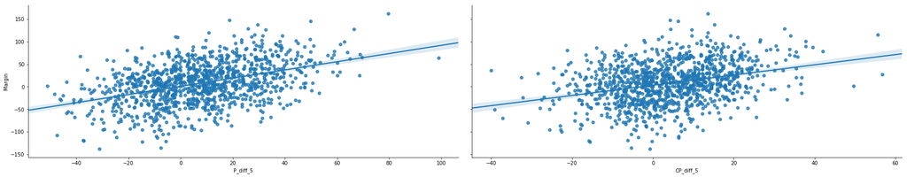

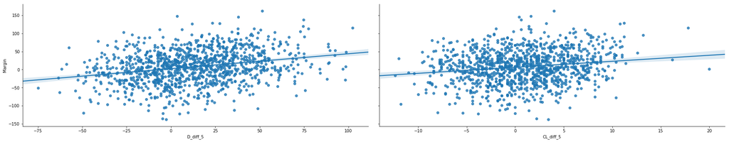

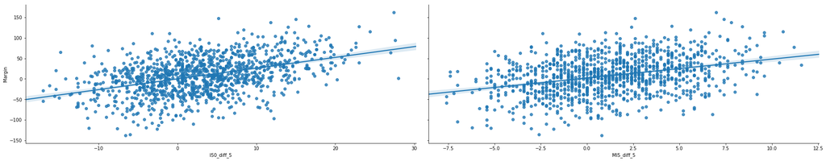

```python
import seaborn as sns
%matplotlib inline
sns.pairplot(flat, x_vars=['P_diff_5', 'CP_diff_5'], y_vars='Margin', size=5, aspect=2.5, kind='reg')
sns.pairplot(flat, x_vars=['D_diff_5', 'CL_diff_5'], y_vars='Margin', size=5, aspect=2.5, kind='reg')
sns.pairplot(flat, x_vars=['I50_diff_5', 'MI5_diff_5'], y_vars='Margin', size=5, aspect=2.5, kind='reg')
```

```python
flat.iloc[:,28:].corr(method="pearson")
# Unsurprisingly, the features / regressors are fairly correlated with one another (collinearity)
# This will tend increase the standard errors of regression coefficients and affect their interpretability
# It may be worthwhile to remove less informative features later
```

|  | P_diff_5 | CP_diff_5 | D_diff_5 | CL_diff_5 | I50_diff_5 | MI5_diff_5 |
| --- | --- | --- | --- | --- | --- | --- |
| P_diff_5 | 1.000000 | 0.376196 | 0.429456 | 0.366425 | 0.740983 | 0.662817 |
| CP_diff_5 | 0.376196 | 1.000000 | 0.406019 | 0.570060 | 0.531434 | 0.133917 |
| D_diff_5 | 0.429456 | 0.406019 | 1.000000 | 0.171184 | 0.551195 | 0.357861 |
| CL_diff_5 | 0.366425 | 0.570060 | 0.171184 | 1.000000 | 0.386733 | 0.030890 |
| I50_diff_5 | 0.740983 | 0.531434 | 0.551195 | 0.386733 | 1.000000 | 0.569471 |
| MI5_diff_5 | 0.662817 | 0.133917 | 0.357861 | 0.030890 | 0.569471 | 1.000000 |

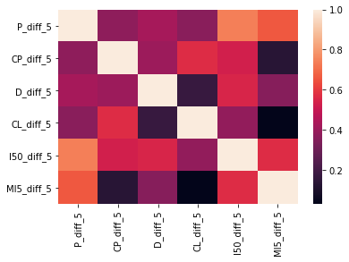

```python
sns.heatmap(flat.iloc[:,28:].corr(method="pearson"))
```

```python
flat.iloc[:,28:].describe()
```

|  | P_diff_5 | CP_diff_5 | D_diff_5 | CL_diff_5 | I50_diff_5 | MI5_diff_5 |
| --- | --- | --- | --- | --- | --- | --- |
| count | 1138.000000 | 1138.000000 | 1138.000000 | 1138.000000 | 1138.000000 | 1138.00000 |
| mean | 7.402460 | 3.789279 | 12.473989 | 0.817399 | 2.905448 | 1.19877 |
| std | 21.455486 | 12.761857 | 29.368756 | 4.703600 | 7.538108 | 3.38200 |
| min | -51.000000 | -40.000000 | -74.800000 | -12.400000 | -17.000000 | -7.60000 |
| 25% | -7.600000 | -4.600000 | -7.400000 | -2.600000 | -2.400000 | -1.20000 |
| 50% | 7.000000 | 3.400000 | 11.900000 | 0.800000 | 2.600000 | 1.00000 |
| 75% | 21.200000 | 12.350000 | 31.950000 | 4.150000 | 7.800000 | 3.40000 |
| max | 99.000000 | 56.800000 | 102.400000 | 20.000000 | 28.000000 | 11.60000 |

# 3. Train the model

The model we will use is the **Logistic Regression** model, also known as the **Logit** model, which is a classification model. This model is particularly suited for this application because its output is a probability that an observation will be in one class over another. Therefore we will take this output to compare against the odds for a particular match.

- If we were only interested in classification, we could have considered models such as kNN, SVM or a Random Forest.
- If we were interested in predicting a margin between teams, a regression model would have been a better alternative.

### 3.1 Setup the training and test data

```python
print(flat.shape)

# drop tied games
model_data = flat[flat.home_win != 0.5]
print(model_data.shape)

# drop finals games
model_data = model_data[~model_data.Round.isin(["QF", "EF", "SF", "PF", "GF"])]
print(model_data.shape)
```

```
(1138, 34)
(1130, 34)
(1076, 34)
```

```python
# split data into train and test sets
train = model_data[model_data.Year != 2017]
print(train.shape)
test = model_data[model_data.Year == 2017]
print(test.shape)
```

```
(888, 34)
(188, 34)
```

### 3.2 Feature selection

```python
# To select the best combination of features, we start by creating a list of all the combinations of features
import itertools
feature_combos = []
for i in range(1, len(features)+1):
    for combo in itertools.combinations(features, i):
        feature_combos.append(list(combo))

# show the first 10 combos
feature_combos[:10]
```

```
[['P_diff_5'],
 ['CP_diff_5'],
 ['D_diff_5'],
 ['CL_diff_5'],
 ['I50_diff_5'],
 ['MI5_diff_5'],
 ['P_diff_5', 'CP_diff_5'],
 ['P_diff_5', 'D_diff_5'],
 ['P_diff_5', 'CL_diff_5'],
 ['P_diff_5', 'I50_diff_5']]
```

```python
# import scikit-learn
from sklearn.linear_model import LogisticRegression
logreg = LogisticRegression()
from sklearn.cross_validation import cross_val_score
```

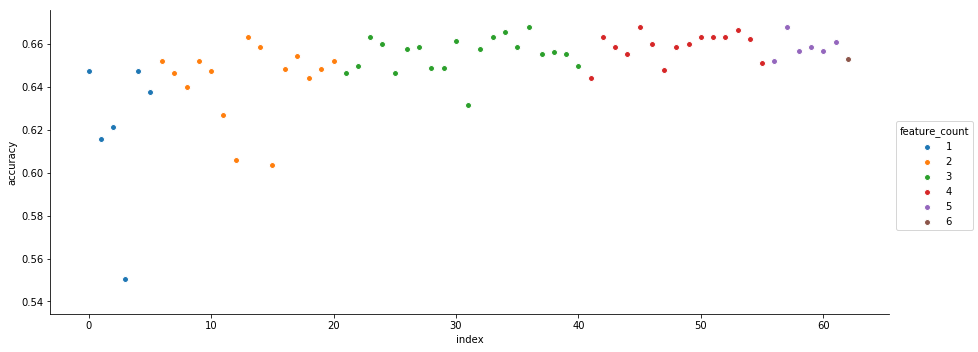

```python
# search for the best performing combo of features using accuracy score from 10-fold cross-validation
# no need for precision, recall, accuracy as wins/losses relatively balanced

y = train["home_win"]
# X = train[features]
combo_accuracies = []

for combo in feature_combos:
    X = train[combo]
    accuracies = cross_val_score(logreg, X, y, cv=10, scoring='accuracy')
    combo_accuracies.append([", ".join(combo), len(combo), accuracies.mean()])

combo_accuracies = pd.DataFrame(combo_accuracies, columns=["combo", "feature_count", "accuracy"])

# plot the 10-fold mean accuracy scores for each feature combo
sns.pairplot(combo_accuracies.reset_index(), x_vars="index", y_vars="accuracy", hue="feature_count", size=5, aspect=2.5)
```

```python
# From the plot, we observe minimal improvement in accuracy as features are added past 2
# Remembering the high correlation between features from before, we suspect overfitting
# Let's evaluate the best 4, 3 and 2 feature models
```

### 3.3 Model selection

Evaluate the best 4, 3 and 2 feature models

```python
combo_accuracies.sort_values("accuracy", ascending=False).head(15)
```

|  | combo | feature_count | accuracy |
| --- | --- | --- | --- |
| 45 | P_diff_5, CP_diff_5, CL_diff_5, MI5_diff_5 | 4 | 0.667731 |
| 57 | P_diff_5, CP_diff_5, D_diff_5, CL_diff_5, MI5_... | 5 | 0.667693 |
| 36 | CP_diff_5, I50_diff_5, MI5_diff_5 | 3 | 0.667642 |
| 53 | CP_diff_5, D_diff_5, I50_diff_5, MI5_diff_5 | 4 | 0.666519 |
| 34 | CP_diff_5, CL_diff_5, I50_diff_5 | 3 | 0.665397 |
| 50 | P_diff_5, CL_diff_5, I50_diff_5, MI5_diff_5 | 4 | 0.663363 |
| 42 | P_diff_5, CP_diff_5, D_diff_5, I50_diff_5 | 4 | 0.663275 |
| 23 | P_diff_5, CP_diff_5, I50_diff_5 | 3 | 0.663237 |
| 52 | CP_diff_5, D_diff_5, CL_diff_5, MI5_diff_5 | 4 | 0.663147 |
| 51 | CP_diff_5, D_diff_5, CL_diff_5, I50_diff_5 | 4 | 0.663137 |
| 33 | CP_diff_5, D_diff_5, MI5_diff_5 | 3 | 0.663135 |
| 13 | CP_diff_5, I50_diff_5 | 2 | 0.663111 |
| 54 | CP_diff_5, CL_diff_5, I50_diff_5, MI5_diff_5 | 4 | 0.662062 |
| 30 | P_diff_5, I50_diff_5, MI5_diff_5 | 3 | 0.661078 |
| 61 | CP_diff_5, D_diff_5, CL_diff_5, I50_diff_5, MI... | 5 | 0.660901 |

```python
# Best 4 features
features = ["P_diff_5", "CP_diff_5", "CL_diff_5", "MI5_diff_5"]
X = train[features]

# use statsmodels to run the regression to show summary
import statsmodels.api as sm
X2 = sm.add_constant(X)
est = sm.Logit(y, X2).fit()
est.summary2()
```

```
Optimization terminated successfully.
         Current function value: 0.600061
         Iterations 5
```

| Model: | Logit | No. Iterations: | 5.0000 |
| --- | --- | --- | --- |
| Dependent Variable: | home_win | Pseudo R-squared: | 0.126 |
| Date: | 2018-05-08 17:31 | AIC: | 1075.7079 |
| No. Observations: | 888 | BIC: | 1099.6528 |
| Df Model: | 4 | Log-Likelihood: | -532.85 |
| Df Residuals: | 883 | LL-Null: | -609.41 |
| Converged: | 1.0000 | Scale: | 1.0000 |

|  | Coef. | Std.Err. | z | P>\|z\| | [0.025 | 0.975] |
| --- | --- | --- | --- | --- | --- | --- |
| const | -0.1181 | 0.0800 | -1.4760 | 0.1399 | -0.2748 | 0.0387 |
| P_diff_5 | 0.0199 | 0.0054 | 3.6987 | 0.0002 | 0.0094 | 0.0304 |
| CP_diff_5 | 0.0428 | 0.0078 | 5.5051 | 0.0000 | 0.0276 | 0.0581 |
| CL_diff_5 | -0.0450 | 0.0203 | -2.2095 | 0.0271 | -0.0848 | -0.0051 |
| MI5_diff_5 | 0.1069 | 0.0316 | 3.3767 | 0.0007 | 0.0448 | 0.1689 |

```python
# Best 3 features
features = ["CP_diff_5", "I50_diff_5", "MI5_diff_5"]
X = train[features]

X2 = sm.add_constant(X)
est = sm.Logit(y, X2).fit()
est.summary2()
```

```
Optimization terminated successfully.
         Current function value: 0.595401
         Iterations 5
```

| Model: | Logit | No. Iterations: | 5.0000 |
| --- | --- | --- | --- |
| Dependent Variable: | home_win | Pseudo R-squared: | 0.132 |
| Date: | 2018-05-08 17:31 | AIC: | 1065.4325 |
| No. Observations: | 888 | BIC: | 1084.5884 |
| Df Model: | 3 | Log-Likelihood: | -528.72 |
| Df Residuals: | 884 | LL-Null: | -609.41 |
| Converged: | 1.0000 | Scale: | 1.0000 |

|  | Coef. | Std.Err. | z | P>\|z\| | [0.025 | 0.975] |
| --- | --- | --- | --- | --- | --- | --- |
| const | -0.1496 | 0.0804 | -1.8611 | 0.0627 | -0.3071 | 0.0079 |
| CP_diff_5 | 0.0260 | 0.0073 | 3.5809 | 0.0003 | 0.0118 | 0.0403 |
| I50_diff_5 | 0.0700 | 0.0147 | 4.7529 | 0.0000 | 0.0411 | 0.0988 |
| MI5_diff_5 | 0.1123 | 0.0278 | 4.0359 | 0.0001 | 0.0577 | 0.1668 |

```python
# Best 2 features
features = ["CP_diff_5", "I50_diff_5"]
X = train[features]

X2 = sm.add_constant(X)
est = sm.Logit(y, X2).fit()
est.summary2()
```

```
Optimization terminated successfully.
         Current function value: 0.604887
         Iterations 5
```

| Model: | Logit | No. Iterations: | 5.0000 |
| --- | --- | --- | --- |
| Dependent Variable: | home_win | Pseudo R-squared: | 0.119 |
| Date: | 2018-05-08 17:31 | AIC: | 1080.2796 |
| No. Observations: | 888 | BIC: | 1094.6465 |
| Df Model: | 2 | Log-Likelihood: | -537.14 |
| Df Residuals: | 885 | LL-Null: | -609.41 |
| Converged: | 1.0000 | Scale: | 1.0000 |

|  | Coef. | Std.Err. | z | P>\|z\| | [0.025 | 0.975] |
| --- | --- | --- | --- | --- | --- | --- |
| const | -0.0781 | 0.0775 | -1.0076 | 0.3137 | -0.2299 | 0.0738 |
| CP_diff_5 | 0.0175 | 0.0069 | 2.5445 | 0.0109 | 0.0040 | 0.0310 |
| I50_diff_5 | 0.1044 | 0.0122 | 8.5363 | 0.0000 | 0.0805 | 0.1284 |

```python
# Finally, select 3 feature model to continue (on the basis of pseudo-R^2, AIC and BIC)
best_features = ["CP_diff_5", "I50_diff_5", "MI5_diff_5"]
X = train[best_features]

logreg.fit(X, y)
print(logreg.intercept_)
print(logreg.coef_)
```

```
[-0.14835332]
[[0.02602506 0.0699692  0.11211293]]
```

## 4. Model evaluation

To evaluate the model, simulate a betting strategy over the 2017 season

### 4.1 Evaluate odds' predictions

```python
# Import the odds table
odds = pd.read_csv("source_data/afl_odds.csv")
odds["prob"] = 1/odds["odds"]
odds.head()
```

|  | date | match_details | season | team_name | odds | prob |
| --- | --- | --- | --- | --- | --- | --- |
| 0 | 2012-03-24 | AFL 2012/Round 1 - 24 March/Greater Western Sy... | AFL 2012 | Greater Western Sydney Giants | 26.0079 | 0.038450 |
| 1 | 2012-03-24 | AFL 2012/Round 1 - 24 March/Greater Western Sy... | AFL 2012 | Sydney Swans | 1.0410 | 0.960615 |
| 2 | 2012-03-29 | AFL 2012/Round 1 - 29 March/Richmond v Carlton | AFL 2012 | Carlton Blues | 1.6250 | 0.615385 |
| 3 | 2012-03-29 | AFL 2012/Round 1 - 29 March/Richmond v Carlton | AFL 2012 | Richmond Tigers | 2.5725 | 0.388727 |
| 4 | 2012-03-30 | AFL 2012/Round 1 - 30 March/Hawthorn v Colling... | AFL 2012 | Collingwood Magpies | 2.4033 | 0.416095 |

```python
# Used Excel to quickly manually match odds and results team names in a lookup table
team_lookup = pd.read_csv("working_data/team_lookup.csv")
team_lookup.head()
```

|  | team_odds | team_std |
| --- | --- | --- |
| 0 | Adelaide | Adelaide |
| 1 | Adelaide Crows | Adelaide |
| 2 | Brisbane Lions | Brisbane Lions |
| 3 | Carlton | Carlton |
| 4 | Carlton Blues | Carlton |

```python
# Merge in the standard team names to the odds table
odds = pd.merge(odds, team_lookup, how="left", left_on="team_name", right_on="team_odds")
odds.head()
```

|  | date | match_details | season | team_name | odds | prob | team_odds | team_std |
| --- | --- | --- | --- | --- | --- | --- | --- | --- |
| 0 | 2012-03-24 | AFL 2012/Round 1 - 24 March/Greater Western Sy... | AFL 2012 | Greater Western Sydney Giants | 26.0079 | 0.038450 | Greater Western Sydney Giants | GWS |
| 1 | 2012-03-24 | AFL 2012/Round 1 - 24 March/Greater Western Sy... | AFL 2012 | Sydney Swans | 1.0410 | 0.960615 | Sydney Swans | Sydney |
| 2 | 2012-03-29 | AFL 2012/Round 1 - 29 March/Richmond v Carlton | AFL 2012 | Carlton Blues | 1.6250 | 0.615385 | Carlton Blues | Carlton |
| 3 | 2012-03-29 | AFL 2012/Round 1 - 29 March/Richmond v Carlton | AFL 2012 | Richmond Tigers | 2.5725 | 0.388727 | Richmond Tigers | Richmond |
| 4 | 2012-03-30 | AFL 2012/Round 1 - 30 March/Hawthorn v Colling... | AFL 2012 | Collingwood Magpies | 2.4033 | 0.416095 | Collingwood Magpies | Collingwood |

```python
# Merge in the implied probability of home win
test = pd.merge(test, odds[["date", "team_std", "prob"]], how="left", left_on=["Date", "Home.Team"], right_on=["date", "team_std"])
test.drop(["date", "team_std"], axis=1, inplace=True)
test.rename(columns={"prob":"home_prob"}, inplace=True)

# Merge in the implied probability of away win
test = pd.merge(test, odds[["date", "team_std", "prob"]], how="left", left_on=["Date", "Away.Team"], right_on=["date", "team_std"])
test.drop(["date", "team_std"], axis=1, inplace=True)
test.rename(columns={"prob":"away_prob"}, inplace=True)

test.head()
```

|  | Date | Round | Home.Team | Home.Goals | Home.Behinds | P_Home | Away.Team | Away.Goals | Away.Behinds | P_Away | ... | I50_Away | MI5_Away | P_diff_5 | CP_diff_5 | D_diff_5 | CL_diff_5 | I50_diff_5 | MI5_diff_5 | home_prob | away_prob |
| --- | --- | --- | --- | --- | --- | --- | --- | --- | --- | --- | --- | --- | --- | --- | --- | --- | --- | --- | --- | --- | --- |
| 0 | 2017-03-23 | R1 | Carlton | 14 | 5 | 89 | Richmond | 20 | 12 | 132 | ... | 61.0 | 16.0 | 9.4 | -2.2 | 7.8 | 3.2 | 2.8 | 1.0 | 0.313785 | 0.687144 |
| 1 | 2017-03-24 | R1 | Collingwood | 12 | 14 | 86 | Footscray | 15 | 10 | 100 | ... | 44.0 | 9.0 | 6.6 | 0.4 | 6.2 | -3.4 | 4.2 | 2.8 | 0.311779 | 0.689227 |
| 2 | 2017-03-25 | R1 | St Kilda | 13 | 12 | 90 | Melbourne | 18 | 12 | 120 | ... | 55.0 | 17.0 | 44.0 | -6.8 | -27.6 | 1.8 | 5.0 | 4.2 | 0.589971 | 0.409836 |
| 3 | 2017-03-25 | R1 | Sydney | 12 | 10 | 82 | Port Adelaide | 17 | 8 | 110 | ... | 56.0 | 7.0 | 16.8 | 25.4 | 60.6 | 3.0 | 7.4 | -2.8 | 0.768108 | 0.230526 |
| 4 | 2017-03-25 | R1 | Essendon | 17 | 14 | 116 | Hawthorn | 12 | 19 | 91 | ... | 59.0 | 9.0 | 6.0 | 20.6 | 33.2 | -3.2 | 2.4 | 1.8 | 0.301951 | 0.699350 |

5 rows × 36 columns

```python
# Check for missing odds
test[test.isnull().any(axis=1)]
# No matches missing odds
```

|  | Date | Round | Home.Team | Home.Goals | Home.Behinds | P_Home | Away.Team | Away.Goals | Away.Behinds | P_Away | ... | I50_Away | MI5_Away | P_diff_5 | CP_diff_5 | D_diff_5 | CL_diff_5 | I50_diff_5 | MI5_diff_5 | home_prob | away_prob |
| --- | --- | --- | --- | --- | --- | --- | --- | --- | --- | --- | --- | --- | --- | --- | --- | --- | --- | --- | --- | --- | --- |

0 rows × 36 columns

```python
# create a column for the outcome the odds predict
test.loc[test["home_prob"] >= 0.5, "odds_predict"] = 1
test.loc[test["home_prob"] < 0.5, "odds_predict"] = 0
```

```python
from sklearn import metrics
odds_accuracy = metrics.accuracy_score(test["home_win"], test["odds_predict"])
print("Odds predict the correct outcome %.2f%% of the time" % (100*odds_accuracy))
```

```
Odds predict the correct outcome 65.43% of the time
```

### 4.2 Evaluate model's predictions

```python
# Predictions (win/loss) from model
X_test = test[best_features]
y_test = test["home_win"]
y_pred = logreg.predict(X_test)
```

```python
model_accuracy = metrics.accuracy_score(y_test, y_pred)
print("Model predicts the correct outcome %.2f%% of the time" % (100*model_accuracy))
```

```
Model predicts the correct outcome 55.32% of the time
```

### 4.3 Evaluate model by simulating betting

```python
# Probabilities from model
y_prob = logreg.predict_proba(X_test)
y_prob = pd.DataFrame(y_prob[:,1], columns=["model_prob"])
y_prob.head()
```

|  | model_prob |
| --- | --- |
| 0 | 0.525582 |
| 1 | 0.615347 |
| 2 | 0.621377 |
| 3 | 0.671844 |
| 4 | 0.680809 |

```python
# Merge in probabilities from model
simulation = pd.concat([test, y_prob], axis=1)

# Compare the predicted probabilities for a home win between our model and the odds
simulation["predict_diff"] = simulation.model_prob - simulation.home_prob
simulation.head()
```

|  | Date | Round | Home.Team | Home.Goals | Home.Behinds | P_Home | Away.Team | Away.Goals | Away.Behinds | P_Away | ... | CP_diff_5 | D_diff_5 | CL_diff_5 | I50_diff_5 | MI5_diff_5 | home_prob | away_prob | odds_predict | model_prob | predict_diff |
| --- | --- | --- | --- | --- | --- | --- | --- | --- | --- | --- | --- | --- | --- | --- | --- | --- | --- | --- | --- | --- | --- |
| 0 | 2017-03-23 | R1 | Carlton | 14 | 5 | 89 | Richmond | 20 | 12 | 132 | ... | -2.2 | 7.8 | 3.2 | 2.8 | 1.0 | 0.313785 | 0.687144 | 0.0 | 0.525582 | 0.211798 |
| 1 | 2017-03-24 | R1 | Collingwood | 12 | 14 | 86 | Footscray | 15 | 10 | 100 | ... | 0.4 | 6.2 | -3.4 | 4.2 | 2.8 | 0.311779 | 0.689227 | 0.0 | 0.615347 | 0.303568 |
| 2 | 2017-03-25 | R1 | St Kilda | 13 | 12 | 90 | Melbourne | 18 | 12 | 120 | ... | -6.8 | -27.6 | 1.8 | 5.0 | 4.2 | 0.589971 | 0.409836 | 1.0 | 0.621377 | 0.031406 |
| 3 | 2017-03-25 | R1 | Sydney | 12 | 10 | 82 | Port Adelaide | 17 | 8 | 110 | ... | 25.4 | 60.6 | 3.0 | 7.4 | -2.8 | 0.768108 | 0.230526 | 1.0 | 0.671844 | -0.096264 |
| 4 | 2017-03-25 | R1 | Essendon | 17 | 14 | 116 | Hawthorn | 12 | 19 | 91 | ... | 20.6 | 33.2 | -3.2 | 2.4 | 1.8 | 0.301951 | 0.699350 | 0.0 | 0.680809 | 0.378858 |

5 rows × 39 columns

```python
# set up betting strategy

# bet only if model gives a prediction with at least 5% implied odds difference to betfair odds
predict_significance = 0.05
```

```python
def bet_strategy(predict_diff):
    if abs(predict_diff) < predict_significance:
        return -1
    elif predict_diff > 0:
        return 1
    else:
        return 0

# place the bets!
simulation["bet"] = simulation["predict_diff"].map(bet_strategy)
```

```python
# bet a constant amount per match (if any). (could consider varying the amount based on predict_diff)
bet_amount = 100
```

```python
# calculate value if bet is won/lost (or no bet)
simulation["bet_val_w"] = np.where(simulation.bet == 1,
                                   bet_amount*(1/simulation.home_prob - 1), # bet home team to win
                                   bet_amount*(1/simulation.away_prob - 1)) # bet away team to win
simulation["bet_val_w"] = np.where(simulation.bet == -1, 0, simulation.bet_val_w) # if no bet, set value = 0
simulation["bet_val_l"] = np.where(simulation.bet == -1, 0, -bet_amount)        # for losing bet, lose bet_amount

# calculate outcome of the bet after each match
simulation["outcome_val"] = np.where(simulation.bet == simulation.home_win, # if bet successful
                                     simulation.bet_val_w, # win value
                                     simulation.bet_val_l) # lose value

# calculate running profit/(loss) balance over the 2017 season
simulation["balance"] = simulation["outcome_val"].cumsum()

simulation.iloc[:,35:].tail()
```

|  | away_prob | odds_predict | model_prob | predict_diff | bet | bet_val_w | bet_val_l | outcome_val | balance |
| --- | --- | --- | --- | --- | --- | --- | --- | --- | --- |
| 183 | 0.582174 | 0.0 | 0.545235 | 0.123312 | 1 | 137.01 | -100 | 137.01 | 1063.04 |
| 184 | 0.061120 | 1.0 | 0.985143 | 0.042191 | -1 | 0.00 | 0 | 0.00 | 1063.04 |
| 185 | 0.113148 | 1.0 | 0.771580 | -0.115811 | 0 | 783.80 | -100 | -100.00 | 963.04 |
| 186 | 0.369031 | 1.0 | 0.674662 | 0.036541 | -1 | 0.00 | 0 | 0.00 | 963.04 |
| 187 | 0.495688 | 1.0 | 0.342340 | -0.164605 | 0 | 101.74 | -100 | -100.00 | 863.04 |

```python
# calculate profit/(loss) over the 2017 season
print("Bet amount per match: $%d" % bet_amount)
print("Total bets placed: %d of %d matches" % (simulation.loc[simulation.bet != -1, "bet"].count(), len(simulation.index)))
print("Total profit over season: $%.2f" % simulation.outcome_val.sum())
print("Return on Investment: %.2f%%" % (100 * simulation.outcome_val.sum() / (100 * simulation.loc[simulation.bet != -1, "bet"].count())))
print("Max positive balance over season: $%.2f" % simulation.balance.max())
print("Max negative balance over season: $%.2f" % -simulation.balance.min())
```

```
Bet amount per match: $100
Total bets placed: 146 of 188 matches
Total profit over season: $863.04
Return on Investment: 5.91%
Max positive balance over season: $2442.11
Max negative balance over season: $230.98
```

### 5. Next steps

Now improve the model further!

- Consider more features
- Tune hyperparameters in the model
- Tune betting strategy parameters
- Using further visualisation to communicate the models to users/customers
- Check for bias and heteroskedasticity in the error term